# Práctica 4-II - Ejercicio 4

# Modelo

- Y: gastos de consumo trimestrales
- X: stock monetario

medidos en billones de dólares en USA entre los años 1952 y 1956. Una versión simplificada de la teorı́a monetaria sugiere el siguiente modelo
$$Y_t = \alpha + \beta X_t + u_t$$

# Ejercicio

## Item a y b

**a) Estime por mínimos cuadrados los parámetros del modelo. b) Grafique los residuos estandarizados versus el tiempo, es decir versus el número de observación.**

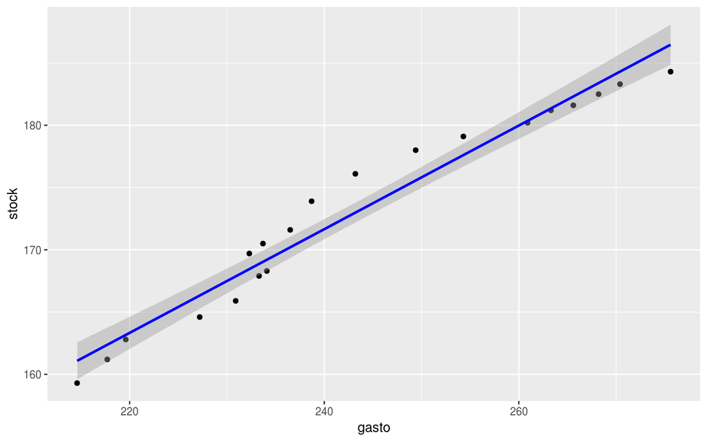

```r
df = read_excel("~/code/Modelo_Lineal_2019/ejercicios/Moneda.xls")
reg = lm(gasto~stock, data=df)
ggplot(df, aes(x=gasto, y=stock)) + geom_point() + stat_smooth(method = "lm", col = "blue")
```

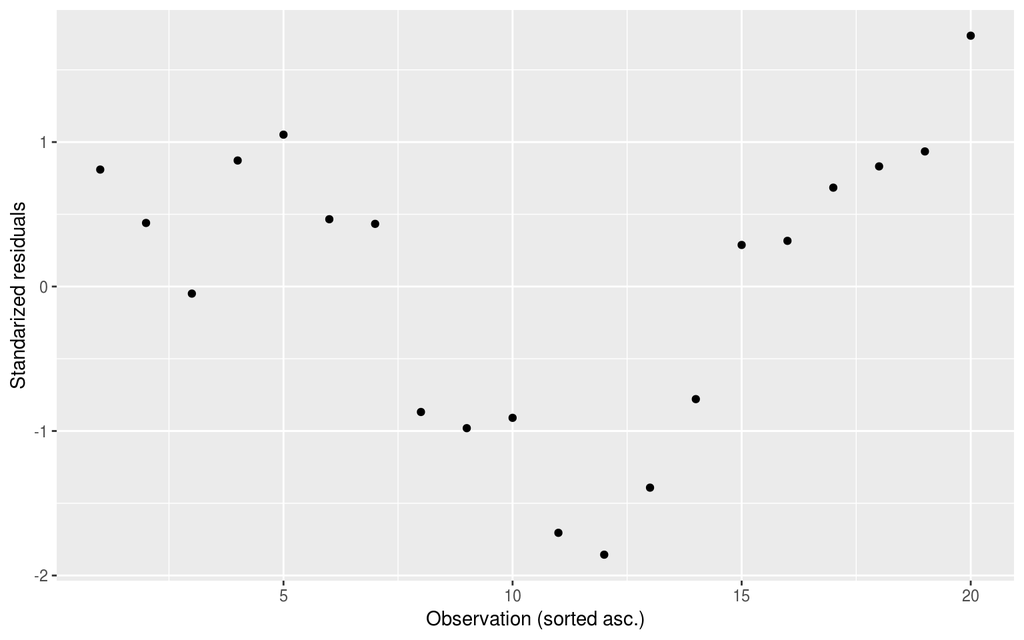

```r
ggplot(df, aes(x=1:nrow(df), y=rstandard(reg))) + geom_point() + xlab('Observation (sorted asc.)') +
ylab("Standarized residuals")
```

## Item c

Calcular el estadístico de Durbin-Watson y testear:
$$H_0: \rho_s = 0 \qquad vs. \qquad H_1:\rho_s = \rho^s$$

```r
# Implementacion 1
dw1 = calculate_durbin_watson_statistic(reg$residuals)
dw1
```

```
## [1] 0.3824024
```

```r
# Implementacion 2
dw2 = sum(diff(reg$residuals)^2) /sum(reg$residuals^2)
dw2
```

```
## [1] 0.3282113
```

El valor del estadístico fue calculado de dos maneras:

- dw1: según https://en.wikipedia.org/wiki/Durbin%E2%80%93Watson_statistic
- dw2: según lmtest::dwtest

Como
$$dw = 2(1-\hat{\rho}),$$
los valores obtenidos en dw1, dw2 evidencian autocorrelación positiva.

También podemos estudiar la autocorrelación de los errores mediante una regresión lineal considerando el modelo propuesto por Durbin-Watson Modelo

```r
res = reg$res
reg_autocorrelation = lm(res[-length(res)] ~ res[-1])
summary(reg_autocorrelation)
```

```
##
## Call:
## lm(formula = res[-length(res)] ~ res[-1])
##
## Residuals:
##     Min      1Q  Median      3Q     Max
## -3.6007 -1.0445  0.3921  1.2564  4.4697
##
## Coefficients:
##             Estimate Std. Error t value Pr(>|t|)
## (Intercept)  -0.2184     0.4934  -0.443    0.664
## res[-1]       0.7707     0.1292   5.967 1.53e-05 ***
## ---
## Signif. codes:  0 '***' 0.001 '**' 0.01 '*' 0.05 '.' 0.1 ' ' 1
##
## Residual standard error: 2.149 on 17 degrees of freedom
## Multiple R-squared:  0.6768, Adjusted R-squared:  0.6578
## F-statistic:  35.6 on 1 and 17 DF,  p-value: 1.531e-05
```

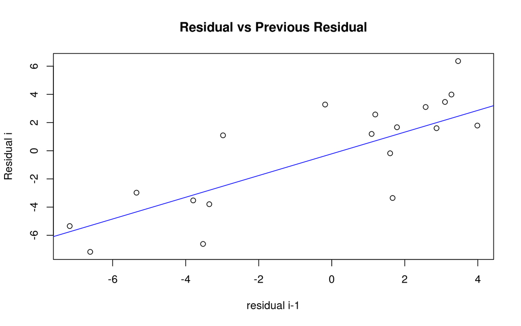

```r
plot(res[-length(res)], res[-1], main="Residual vs Previous Residual", xlab="residual i-1",ylab="Residual i")
abline(reg_autocorrelation, col="blue")
```

En la figura anterior se evidencia la autocorrelación positiva de los residuos. El ajuste y el estimador de la pendiente son significativos:

- F-statistic: 35.6 on 1 and 17 DF
- p-value: 1.531e-05

## Item d y e

Usando $\rho$ calculado anteriormente transforme los datos de la siguiente manera:
$$Y_t^∗ = Y_t − \hat\rho Y_{t-1}$$
$$X_t^∗ = X_t − \hat\rho X_{t-1}$$

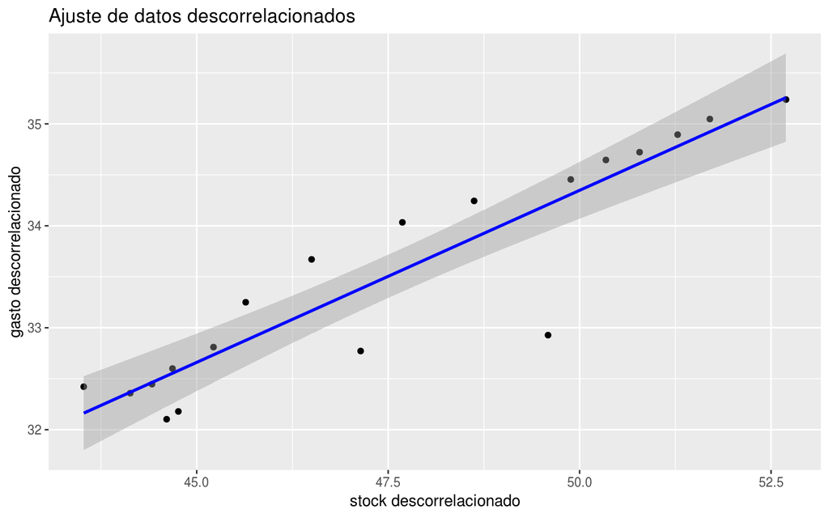

```r
rho = 1 - dw1/2
n = ncol(df)

gasto_star = df$gasto[-1] - rho * df$gasto[-n]
stock_star = df$stock[-1] - rho * df$stock[-n]
df_star = data.frame(Y=gasto_star, X=stock_star)
reg = lm(df_star$Y~df_star$X)

ggplot(df_star, aes(x=gasto_star, y=stock_star)) +  geom_point() +
  stat_smooth(method = "lm", col = "blue") + ggtitle("Ajuste de datos descorrelacionados") + ylab("gasto descorrelacionado") + xlab("stock descorrelacionado")
```

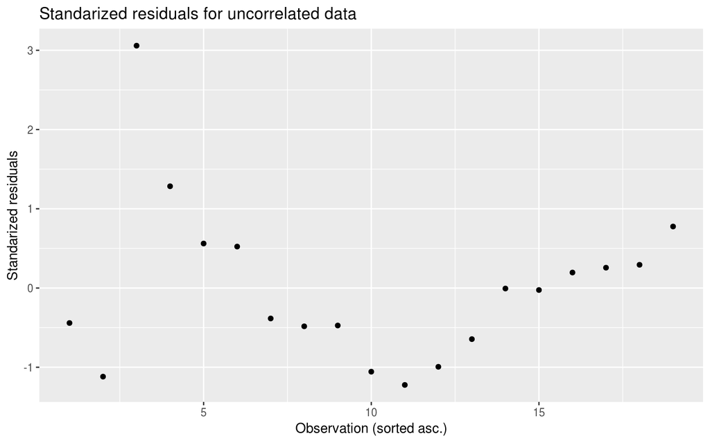

```r
ggplot(df_star, aes(x=1:nrow(df_star), y=rstandard(reg))) + geom_point() + xlab('Observation (sorted asc.)') +
ylab("Standarized residuals") + ggtitle("Standarized residuals for uncorrelated data")
```

```r
# Durbin watson statistic
calculate_durbin_watson_statistic(reg$residuals)
```

```
## [1] 1.319781
```

Luego de la transformación propuesta, el valor del estadístico de Durbin-Watson cambió de: $dw \approx 0.38 \quad \rightarrow \quad dw \approx 1.32$

Mariano Barraco

2019-06-22